# Entregable 1 - Data cleaning

```python
import pandas as pd
import numpy as np
import matplotlib.pyplot as plt
import seaborn as sns
from sklearn.preprocessing import LabelEncoder, MinMaxScaler, OrdinalEncoder
from numpy.lib.histograms import histogram
```

Importar dataframe y guardarlo en una variable

```python
bmw = pd.read_csv("bmw_pricing_v3.csv")
```

```python
bmw.head()
```

|  | marca | modelo | km | potencia | fecha_registro | tipo_gasolina | color | tipo_coche | volante_regulable | aire_acondicionado | camara_trasera | asientos_traseros_plegables | elevalunas_electrico | bluetooth | gps | alerta_lim_velocidad | precio | fecha_venta |
| --- | --- | --- | --- | --- | --- | --- | --- | --- | --- | --- | --- | --- | --- | --- | --- | --- | --- | --- |
| 0 | NaN | 118 | 140411.0000 | 100.0000 | 2012-02-01 | diesel | black | NaN | True | True | False | NaN | True | NaN | True | NaN | 11300.0000 | 2018-01-01 |
| 1 | BMW | M4 | 13929.0000 | 317.0000 | NaN | petrol | grey | convertible | True | True | False | NaN | False | True | True | True | 69700.0000 | 2018-02-01 |
| 2 | BMW | 320 | 183297.0000 | 120.0000 | 2012-04-01 | diesel | white | NaN | False | False | False | NaN | True | False | True | False | 10200.0000 | 2018-02-01 |
| 3 | BMW | 420 | 128035.0000 | 135.0000 | NaN | diesel | red | convertible | True | True | False | NaN | True | True | True | NaN | 25100.0000 | 2018-02-01 |
| 4 | BMW | 425 | 97097.0000 | 160.0000 | NaN | diesel | silver | NaN | True | True | False | False | False | True | True | True | 33400.0000 | 2018-04-01 |

Empiezo a hacer descripción del data frame, para ver dimensiones, tipos de variables.

El dataframe inicial tiene 18 variables:

```
* Categóricas - 14
* Floats - 3
* Boolean - 1
```

```python
bmw.shape
```

```
(4843, 18)
```

```python
bmw.info()
```

```
<class 'pandas.core.frame.DataFrame'>
RangeIndex: 4843 entries, 0 to 4842
Data columns (total 18 columns):
 #   Column                       Non-Null Count  Dtype
---  ------                       --------------  -----
 0   marca                        3873 non-null   object
 1   modelo                       4840 non-null   object
 2   km                           4841 non-null   float64
 3   potencia                     4842 non-null   float64
 4   fecha_registro               2420 non-null   object
 5   tipo_gasolina                4838 non-null   object
 6   color                        4398 non-null   object
 7   tipo_coche                   3383 non-null   object
 8   volante_regulable            4839 non-null   object
 9   aire_acondicionado           4357 non-null   object
 10  camara_trasera               4841 non-null   object
 11  asientos_traseros_plegables  1452 non-null   object
 12  elevalunas_electrico         4841 non-null   object
 13  bluetooth                    4115 non-null   object
 14  gps                          4843 non-null   bool
 15  alerta_lim_velocidad         4115 non-null   object
 16  precio                       4837 non-null   float64
 17  fecha_venta                  4842 non-null   object
dtypes: bool(1), float64(3), object(14)
memory usage: 648.1+ KB
```

```python
## dtype usarlo para definir listas con tipos de variables

(bmw["volante_regulable"]).dtype
```

```
dtype('O')
```

```python
bmw.isnull().sum()
```

```
marca                           970
modelo                            3
km                                2
potencia                          1
fecha_registro                 2423
tipo_gasolina                     5
color                           445
tipo_coche                     1460
volante_regulable                 4
aire_acondicionado              486
camara_trasera                    2
asientos_traseros_plegables    3391
elevalunas_electrico              2
bluetooth                       728
gps                               0
alerta_lim_velocidad            728
precio                            6
fecha_venta                       1
dtype: int64
```

```python
print(type(bmw.isnull().sum() / len(bmw)), "\n", type(bmw.columns))
```

```
<class 'pandas.core.series.Series'>
 <class 'pandas.core.indexes.base.Index'>
```

```python
## este dataframe también lo puedo hacer como un diccionario, con las key_values los nombres de columnas y los values como la lista de valores.
# Me lo devuelve como lista vertical, sin tener que transponer

nulos = pd.DataFrame(
    (
        np.array([(bmw.isnull().sum()), ((bmw.isnull().sum() / len(bmw)).round(4))])
    ).transpose(),
    index=bmw.columns,
    columns=["nulls_value", "nulls_prop"],
).sort_values("nulls_prop", ascending=False)
```

```python
bmw.isnull().sum() / len(bmw)
```

```
marca                         0.2003
modelo                        0.0006
km                            0.0004
potencia                      0.0002
fecha_registro                0.5003
tipo_gasolina                 0.0010
color                         0.0919
tipo_coche                    0.3015
volante_regulable             0.0008
aire_acondicionado            0.1004
camara_trasera                0.0004
asientos_traseros_plegables   0.7002
elevalunas_electrico          0.0004
bluetooth                     0.1503
gps                           0.0000
alerta_lim_velocidad          0.1503
precio                        0.0012
fecha_venta                   0.0002
dtype: float64
```

```python
## Busco si tiene duplicados ##

## Keep hace que

bmw[bmw.duplicated(keep=False)]
```

|  | marca | modelo | km | potencia | fecha_registro | tipo_gasolina | color | tipo_coche | volante_regulable | aire_acondicionado | camara_trasera | asientos_traseros_plegables | elevalunas_electrico | bluetooth | gps | alerta_lim_velocidad | precio | fecha_venta |
| --- | --- | --- | --- | --- | --- | --- | --- | --- | --- | --- | --- | --- | --- | --- | --- | --- | --- | --- |

```python
### Paso los booleans que están como objets a booleans ###

bmw.info()
```

```
<class 'pandas.core.frame.DataFrame'>
RangeIndex: 4843 entries, 0 to 4842
Data columns (total 18 columns):
 #   Column                       Non-Null Count  Dtype
---  ------                       --------------  -----
 0   marca                        3873 non-null   object
 1   modelo                       4840 non-null   object
 2   km                           4841 non-null   float64
 3   potencia                     4842 non-null   float64
 4   fecha_registro               2420 non-null   object
 5   tipo_gasolina                4838 non-null   object
 6   color                        4398 non-null   object
 7   tipo_coche                   3383 non-null   object
 8   volante_regulable            4839 non-null   object
 9   aire_acondicionado           4357 non-null   object
 10  camara_trasera               4841 non-null   object
 11  asientos_traseros_plegables  1452 non-null   object
 12  elevalunas_electrico         4841 non-null   object
 13  bluetooth                    4115 non-null   object
 14  gps                          4843 non-null   bool
 15  alerta_lim_velocidad         4115 non-null   object
 16  precio                       4837 non-null   float64
 17  fecha_venta                  4842 non-null   object
dtypes: bool(1), float64(3), object(14)
memory usage: 648.1+ KB
```

Cambios en los tipos de datos de las variables:

```
* fecha_registro --> date
* de: volante_regulable[8] hasta: alerta_lim_velocidad[15]  --> object a boolean --> boolean a integer
* fecha_venta --> date
```

```python
# c.astype('Int64')

# bmw['volante_regulable']
```

```python
for i in bmw.iloc[:, 8:16]:
    print(i)
```

```
volante_regulable
aire_acondicionado
camara_trasera
asientos_traseros_plegables
elevalunas_electrico
bluetooth
gps
alerta_lim_velocidad
```

```python
## Cambio los booleanos directamente a integer

for i in bmw.iloc[:, 8:16]:
    bmw[i] = bmw[i].astype("Int64")

print(bmw.head())

print(bmw.info())
print(bmw["volante_regulable"].dtype)
print(bmw["volante_regulable"])
```

```
  marca modelo          km  potencia fecha_registro tipo_gasolina   color
0   NaN    118 140411.0000  100.0000     2012-02-01        diesel   black  \
1   BMW     M4  13929.0000  317.0000            NaN        petrol    grey
2   BMW    320 183297.0000  120.0000     2012-04-01        diesel   white
3   BMW    420 128035.0000  135.0000            NaN        diesel     red
4   BMW    425  97097.0000  160.0000            NaN        diesel  silver

    tipo_coche  volante_regulable  aire_acondicionado  camara_trasera
0          NaN                  1                   1               0  \
1  convertible                  1                   1               0
2          NaN                  0                   0               0
3  convertible                  1                   1               0
4          NaN                  1                   1               0

   asientos_traseros_plegables  elevalunas_electrico  bluetooth  gps
```

[output cut: 90 more lines]

```python
(bmw["volante_regulable"].astype("boolean")).value_counts(dropna=False, normalize=True)
```

```
volante_regulable
True    0.5497
False   0.4495
<NA>    0.0008
Name: proportion, dtype: Float64
```

```python
bmw.head()
```

|  | marca | modelo | km | potencia | fecha_registro | tipo_gasolina | color | tipo_coche | volante_regulable | aire_acondicionado | camara_trasera | asientos_traseros_plegables | elevalunas_electrico | bluetooth | gps | alerta_lim_velocidad | precio | fecha_venta |
| --- | --- | --- | --- | --- | --- | --- | --- | --- | --- | --- | --- | --- | --- | --- | --- | --- | --- | --- |
| 0 | NaN | 118 | 140411.0000 | 100.0000 | 2012-02-01 | diesel | black | NaN | 1 | 1 | 0 | <NA> | 1 | <NA> | 1 | <NA> | 11300.0000 | 2018-01-01 |
| 1 | BMW | M4 | 13929.0000 | 317.0000 | NaN | petrol | grey | convertible | 1 | 1 | 0 | <NA> | 0 | 1 | 1 | 1 | 69700.0000 | 2018-02-01 |
| 2 | BMW | 320 | 183297.0000 | 120.0000 | 2012-04-01 | diesel | white | NaN | 0 | 0 | 0 | <NA> | 1 | 0 | 1 | 0 | 10200.0000 | 2018-02-01 |
| 3 | BMW | 420 | 128035.0000 | 135.0000 | NaN | diesel | red | convertible | 1 | 1 | 0 | <NA> | 1 | 1 | 1 | <NA> | 25100.0000 | 2018-02-01 |
| 4 | BMW | 425 | 97097.0000 | 160.0000 | NaN | diesel | silver | NaN | 1 | 1 | 0 | 0 | 0 | 1 | 1 | 1 | 33400.0000 | 2018-04-01 |

```python
## pasar fecha_registro y fecha_venta a date

for i in ["fecha_registro", "fecha_venta"]:
    bmw[i] = pd.to_datetime(bmw[i])

print(bmw.info())
```

```
<class 'pandas.core.frame.DataFrame'>
RangeIndex: 4843 entries, 0 to 4842
Data columns (total 18 columns):
 #   Column                       Non-Null Count  Dtype
---  ------                       --------------  -----
 0   marca                        3873 non-null   object
 1   modelo                       4840 non-null   object
 2   km                           4841 non-null   float64
 3   potencia                     4842 non-null   float64
 4   fecha_registro               2420 non-null   datetime64[ns]
 5   tipo_gasolina                4838 non-null   object
 6   color                        4398 non-null   object
 7   tipo_coche                   3383 non-null   object
 8   volante_regulable            4839 non-null   Int64
 9   aire_acondicionado           4357 non-null   Int64
 10  camara_trasera               4841 non-null   Int64
 11  asientos_traseros_plegables  1452 non-null   Int64
 12  elevalunas_electrico         4841 non-null   Int64
 13  bluetooth                    4115 non-null   Int64
 14  gps                          4843 non-null   Int64
 15  alerta_lim_velocidad         4115 non-null   Int64
 16  precio                       4837 non-null   float64
 17  fecha_venta                  4842 non-null   datetime64[ns]
dtypes: Int64(8), datetime64[ns](2), float64(3), object(5)
memory usage: 719.0+ KB
None
```

```python
## Lista para ver las etiquetas de los tipos de datos (Dtype)

for i in bmw:
    print(
        bmw[i].dtype,
        bmw[i].dtype.kind,
    )
```

```
object O
object O
float64 f
float64 f
datetime64[ns] M
object O
object O
object O
Int64 i
Int64 i
Int64 i
Int64 i
Int64 i
Int64 i
Int64 i
Int64 i
float64 f
datetime64[ns] M
```

```python
# Primer checkpoint

bmw2 = bmw.copy()
```

Procesamiento de Nulos

- asientos_traseros_plegables: variable eliminada. La alta proporción de nulos en la muestra (70%) quita representatividad de la variable en la muestra, no aportando suficiente información para el modelo.

```python
nulos
```

|  | nulls_value | nulls_prop |
| --- | --- | --- |
| asientos_traseros_plegables | 3391.0000 | 0.7002 |
| fecha_registro | 2423.0000 | 0.5003 |
| tipo_coche | 1460.0000 | 0.3015 |
| marca | 970.0000 | 0.2003 |
| alerta_lim_velocidad | 728.0000 | 0.1503 |
| bluetooth | 728.0000 | 0.1503 |
| aire_acondicionado | 486.0000 | 0.1004 |
| color | 445.0000 | 0.0919 |
| precio | 6.0000 | 0.0012 |
| tipo_gasolina | 5.0000 | 0.0010 |
| volante_regulable | 4.0000 | 0.0008 |
| modelo | 3.0000 | 0.0006 |
| camara_trasera | 2.0000 | 0.0004 |
| elevalunas_electrico | 2.0000 | 0.0004 |
| km | 2.0000 | 0.0004 |
| potencia | 1.0000 | 0.0002 |
| fecha_venta | 1.0000 | 0.0002 |
| gps | 0.0000 | 0.0000 |

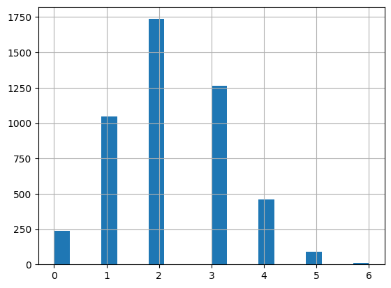

```python
## Vamos a buscar si tenemos FILAS con gran presencia de nulos

bmw.isnull().sum(axis=1)

bmw.isnull().sum(axis=1).hist(bins=20)
```

```python
print(
    "máximo de nulos por fila: ",
    bmw.isnull().sum(axis=1).max(),
    "\n",
    "mínimo de nulos por fila: ",
    (bmw.isnull().sum(axis=1) == 6).sum(),
)
```

```
máximo de nulos por fila:  6
 mínimo de nulos por fila:  10
```

```python
((bmw.isnull().sum(axis=1) == 6).astype(int)).sum()

## La mayor cantidad de nulos por filas es de 6, situación que se da en 10 ocasiones. Por lo que no es
## necesario eliminar filas completas del dataset
```

```
10
```

```python
## La variable asientos_traseros plegables tiene 70% de observaciones nulas. Elegimos eliminar la variable

bmw2["asientos_traseros_plegables"].value_counts(dropna=False) / len(
    bmw2["asientos_traseros_plegables"]
)
```

```
asientos_traseros_plegables
<NA>   0.7002
0      0.2375
1      0.0624
Name: count, dtype: Float64
```

```
asientos_traseros_plegables
0   0.7920
1   0.2080
Name: proportion, dtype: Float64
```

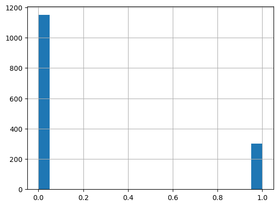

```python
bmw2["asientos_traseros_plegables"].hist(bins=20)

print(bmw2["asientos_traseros_plegables"].value_counts(normalize=True))
```

```python
bmw2[bmw2["asientos_traseros_plegables"].isnull()]
```

|  | marca | modelo | km | potencia | fecha_registro | tipo_gasolina | color | tipo_coche | volante_regulable | aire_acondicionado | camara_trasera | asientos_traseros_plegables | elevalunas_electrico | bluetooth | gps | alerta_lim_velocidad | precio | fecha_venta |
| --- | --- | --- | --- | --- | --- | --- | --- | --- | --- | --- | --- | --- | --- | --- | --- | --- | --- | --- |
| 0 | NaN | 118 | 140411.0000 | 100.0000 | 2012-02-01 | diesel | black | NaN | 1 | 1 | 0 | <NA> | 1 | <NA> | 1 | <NA> | 11300.0000 | 2018-01-01 |
| 1 | BMW | M4 | 13929.0000 | 317.0000 | NaT | petrol | grey | convertible | 1 | 1 | 0 | <NA> | 0 | 1 | 1 | 1 | 69700.0000 | 2018-02-01 |
| 2 | BMW | 320 | 183297.0000 | 120.0000 | 2012-04-01 | diesel | white | NaN | 0 | 0 | 0 | <NA> | 1 | 0 | 1 | 0 | 10200.0000 | 2018-02-01 |
| 3 | BMW | 420 | 128035.0000 | 135.0000 | NaT | diesel | red | convertible | 1 | 1 | 0 | <NA> | 1 | 1 | 1 | <NA> | 25100.0000 | 2018-02-01 |
| 6 | BMW | 325 | 205219.0000 | 145.0000 | NaT | diesel | grey | convertible | 1 | 1 | 0 | <NA> | 1 | 1 | 1 | 1 | 12400.0000 | 2018-02-01 |
| ... | ... | ... | ... | ... | ... | ... | ... | ... | ... | ... | ... | ... | ... | ... | ... | ... | ... | ... |
| 4837 | BMW | 218 Gran Tourer | 66770.0000 | 110.0000 | NaT | diesel | blue | van | 0 | 1 | 0 | <NA> | 0 | 0 | 1 | 0 | 13400.0000 | 2018-07-01 |
| 4838 | BMW | 218 Gran Tourer | 39743.0000 | 110.0000 | NaT | diesel | black | NaN | 0 | 1 | 0 | <NA> | 0 | 0 | 1 | 0 | 14600.0000 | 2018-08-01 |
| 4839 | BMW | 218 Active Tourer | 49832.0000 | 100.0000 | 2015-06-01 | diesel | grey | NaN | 0 | 1 | 0 | <NA> | 0 | 0 | 1 | 1 | 17500.0000 | 2018-08-01 |
| 4840 | BMW | 218 Gran Tourer | 19633.0000 | 110.0000 | 2015-10-01 | diesel | grey | van | 0 | 1 | 0 | <NA> | 0 | 0 | 1 | 1 | 17000.0000 | 2018-09-01 |
| 4842 | BMW | 525 | 195840.0000 | 160.0000 | NaT | diesel | grey | NaN | 1 | <NA> | 0 | <NA> | 1 | 0 | 1 | 1 | 15500.0000 | 2018-09-01 |

3391 rows × 18 columns

```python
del bmw2["asientos_traseros_plegables"]
```

```python
bmw2.head()
```

|  | marca | modelo | km | potencia | fecha_registro | tipo_gasolina | color | tipo_coche | volante_regulable | aire_acondicionado | camara_trasera | elevalunas_electrico | bluetooth | gps | alerta_lim_velocidad | precio | fecha_venta |
| --- | --- | --- | --- | --- | --- | --- | --- | --- | --- | --- | --- | --- | --- | --- | --- | --- | --- |
| 0 | NaN | 118 | 140411.0000 | 100.0000 | 2012-02-01 | diesel | black | NaN | 1 | 1 | 0 | 1 | <NA> | 1 | <NA> | 11300.0000 | 2018-01-01 |
| 1 | BMW | M4 | 13929.0000 | 317.0000 | NaT | petrol | grey | convertible | 1 | 1 | 0 | 0 | 1 | 1 | 1 | 69700.0000 | 2018-02-01 |
| 2 | BMW | 320 | 183297.0000 | 120.0000 | 2012-04-01 | diesel | white | NaN | 0 | 0 | 0 | 1 | 0 | 1 | 0 | 10200.0000 | 2018-02-01 |
| 3 | BMW | 420 | 128035.0000 | 135.0000 | NaT | diesel | red | convertible | 1 | 1 | 0 | 1 | 1 | 1 | <NA> | 25100.0000 | 2018-02-01 |
| 4 | BMW | 425 | 97097.0000 | 160.0000 | NaT | diesel | silver | NaN | 1 | 1 | 0 | 0 | 1 | 1 | 1 | 33400.0000 | 2018-04-01 |

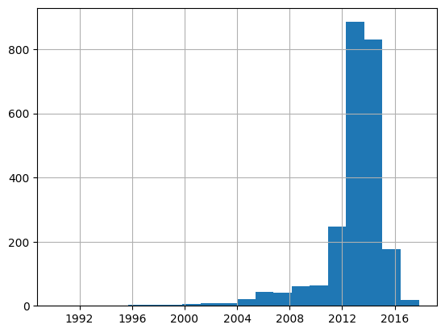

```python
bmw2["fecha_registro"].hist(bins=20)
```

```python
print(
    bmw2["fecha_registro"].value_counts(),
    "\n",
    "media fecha de registro: ",
    bmw2["fecha_registro"].mean(),
    "\n",
    "mediana fecha de registro: ",
    bmw2["fecha_registro"].median(),
    "\n",
    "moda fecha de registro: ",
    bmw2["fecha_registro"].mode(),
)
```

```
fecha_registro
2013-07-01    93
2014-03-01    83
2014-05-01    81
2013-01-01    78
2013-10-01    77
              ..
2007-01-01     1
1990-03-01     1
2006-11-01     1
1994-01-01     1
2005-09-01     1
Name: count, Length: 180, dtype: int64
 media fecha de registro:  2012-12-06 07:35:12.396694016
 mediana fecha de registro:  2013-07-01 00:00:00
 moda fecha de registro:  0   2013-07-01
Name: fecha_registro, dtype: datetime64[ns]
```

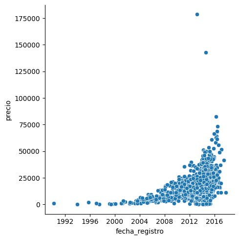

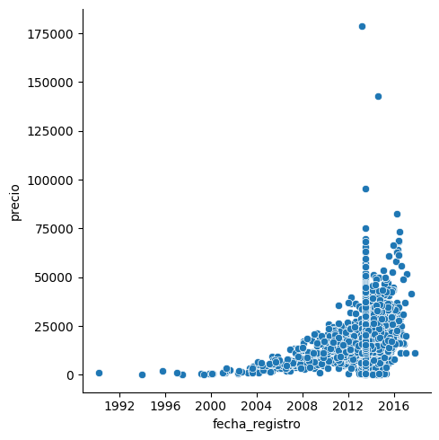

```python
### Reemplazo los nulos de 'fecha_registro' por la mediana, valor 2013-07-01, ya que respeta la distribución previa de la muestra. Además,
# en la muestra original se verifica la frecuencia relativa importante del año 2013


bmw2["fecha_registro"].fillna(bmw2["fecha_registro"].median(), inplace=True)


sns.relplot(y=bmw["precio"], x=bmw["fecha_registro"], data=bmw, kind="scatter")

sns.relplot(y=bmw2["precio"], x=bmw2["fecha_registro"], data=bmw2, kind="scatter")
```